# powerRangers

Lily-Rose

## R Markdown

Hello, World. This is my first attempt at participating in tidytuesday, with a dataset on the Power Rangers franchise.

```r
library(tidyverse)
power_rangers_episodes <- readr::read_csv('https://raw.githubusercontent.com/rfordatascience/tidytuesday/master/data/2024/2024-08-27/power_rangers_episodes.csv')
power_rangers_seasons <- readr::read_csv('https://raw.githubusercontent.com/rfordatascience/tidytuesday/master/data/2024/2024-08-27/power_rangers_seasons.csv')
```

### Top 25 most popular Power Rangers episodes

It looks like Beast Morphers, Lost Galaxy and Time Force have the most popular episodes.

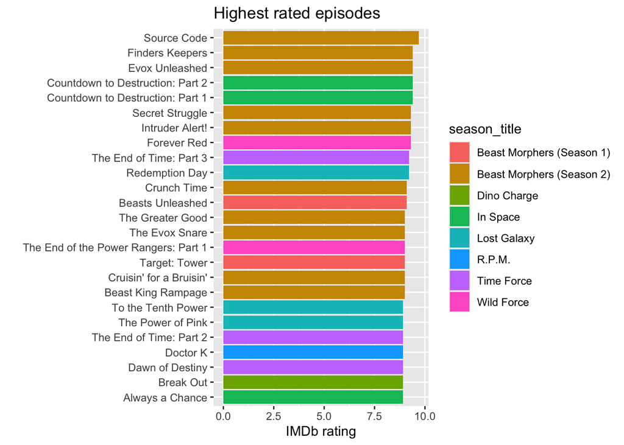

```r
power_rangers_episodes %>%
  arrange(desc(IMDB_rating)) %>%
  head(25) %>%
  ggplot(aes(fct_reorder(episode_title, IMDB_rating), IMDB_rating, fill = season_title)) +
  geom_col() +
  coord_flip() +
  labs(x = "", y = "IMDb rating", title = "Highest rated episodes")
```

### Top 25 least popular Power Rangers episodes

It looks like Turbo, Zeo and Mighty Morphin have the least popular episodes.

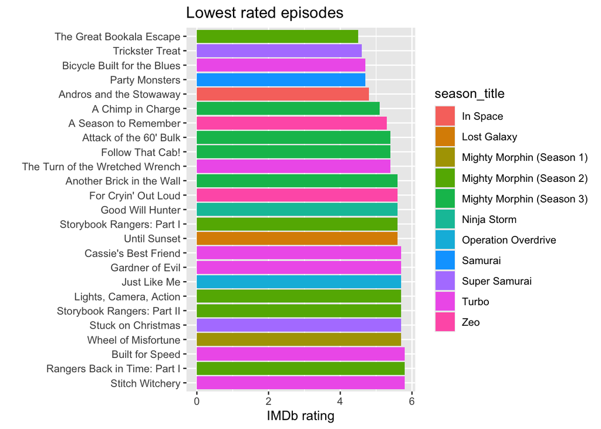

```r
power_rangers_episodes %>%
  arrange(desc(IMDB_rating)) %>%
  tail(25) %>%
  ggplot(aes(fct_rev(fct_reorder(episode_title, IMDB_rating)), IMDB_rating, fill = season_title)) +
  geom_col() +
  coord_flip() +
  labs(x = "", y = "IMDb rating", title = "Lowest rated episodes")
```

### Highest rated seasons

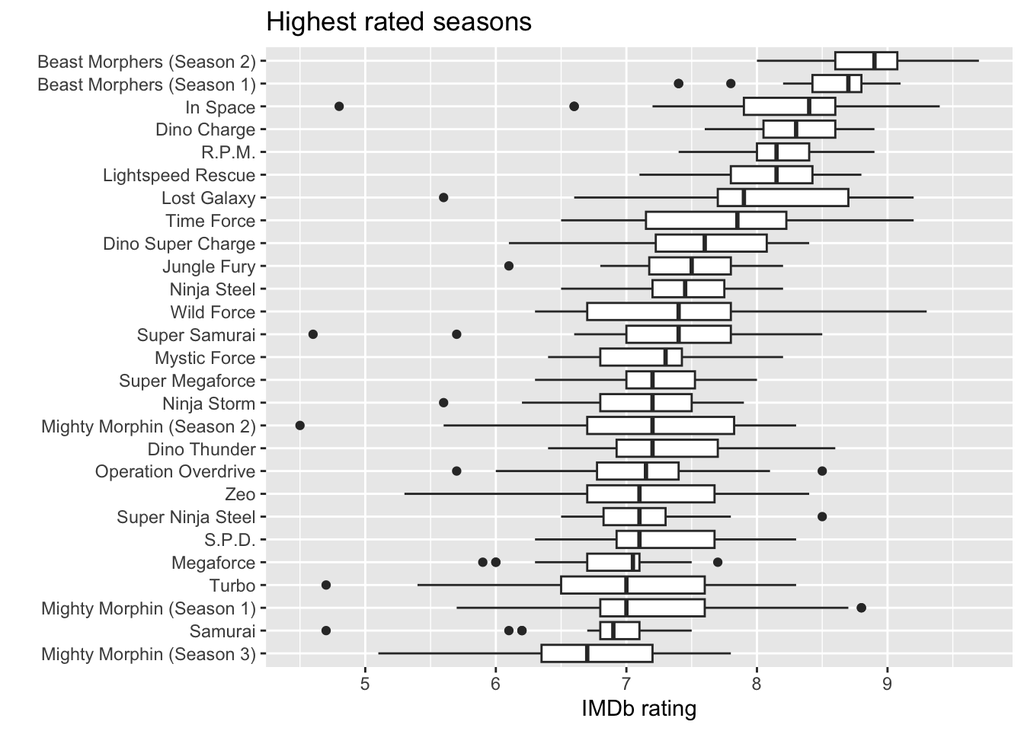

```r
power_rangers_episodes %>%
  ggplot(aes(fct_reorder(season_title, IMDB_rating), IMDB_rating)) +
  geom_boxplot() +
  coord_flip() +
  labs(x = "", y = "IMDb rating", title = "Highest rated seasons")
```

### Ratings overtime

Ratings have increased overtime, especially in the 90s and late 2010s

[figure not shown]

```r
power_rangers_episodes %>%
  group_by(year = floor(year(air_date))) %>%
  summarise(average_rating = mean(IMDB_rating, na.rm = TRUE)) %>%
  ggplot(aes(x = year, y = average_rating)) +
  geom_line() +
  geom_smooth() +
  labs(x = "Year", y = "Average IMDb Rating", title = "Average IMDb Rating by year")
```

### Average number of ratings per year

The number of people leaving ratings falls off heavily during the 90s and early 2000s, and then stabilises until the present. I’m unsure if this was a general trend in the industry, or specific to the Power Rangers franchise.

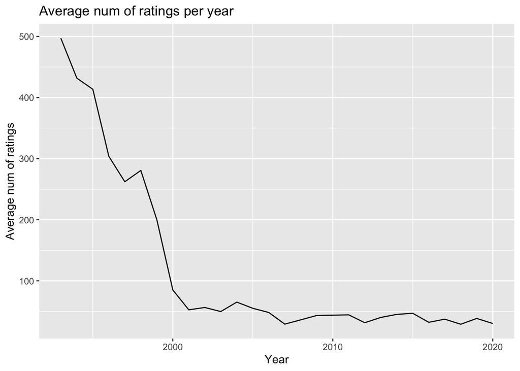

```r
power_rangers_episodes %>%
  group_by(year = floor(year(air_date))) %>%
  summarise(total_votes = mean(total_votes, na.rm = TRUE)) %>%
  ggplot(aes(x = year, y = total_votes)) +
  geom_line() +
  labs(x = "Year", y = "Average num of ratings", title = "Average num of ratings per year")
```

### Ratings by producer

Ratings are fairly consistent across all producers

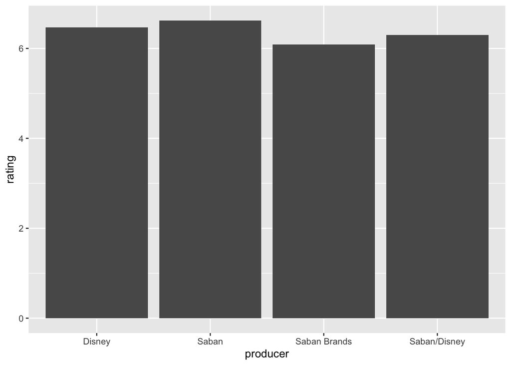

```r
power_rangers_seasons %>%
  group_by(producer) %>%
  summarise(rating = mean(IMDB_rating)) %>%
  ggplot(aes(rating, producer)) +
  geom_col() +
  coord_flip()
```

### Season length by season ratings

Ratings somewhat increased as season length increased, up to about 40-45 episodes, and then slowly decreased

[figure not shown]

```r
power_rangers_seasons %>%
  ggplot(aes(number_of_episodes, IMDB_rating)) +
  geom_point() +
  geom_smooth() +
  expand_limits(y = 0)
```

### Season length by episode ratings

When we look at episode ratings we see a slightly different story, with ratings being fairly consistent up until about 40-45 episodes in, where it begins to decrease slightly.

[figure not shown]

```r
power_rangers_episodes %>%
  ggplot(aes(episode_num, IMDB_rating)) +
  geom_jitter() +
  geom_smooth() +
  expand_limits(y = 0)
```

### Ratings per show

Most seasons have some ups and downs, but Super Samurai, In Space, Lost Galaxy and Mighty Morphin, seem to have more ratings variability than some other shows.

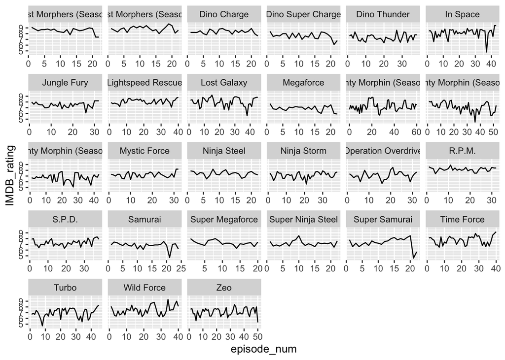

```r
power_rangers_episodes %>%
  ggplot(aes(episode_num, IMDB_rating)) +
  geom_line() +
  facet_wrap(~season_title, scales = "free_x")
```